# Take-home Exercise 3: Geospatial Analytics for Urban Sustainability

Where HDB residents board the train on weekday mornings, and how the Jurong Region Line and Cross Island Line phase 1 would change that. A Huff model of 10,817 HDB blocks and 184 stations.

## Contents

One question: where do HDB residents board the train on weekday mornings, and how would the planned Jurong Region Line (JRL) and Cross Island Line phase 1 (CRL) change that?

1. Why station demand is needed before a station opens
2. The data, and how far they can be trusted
3. How the model shares out each block’s residents
4. What makes a station attract riders
5. How accurate the model is
6. Which new stations have the most HDB residents nearby
7. Where boardings move when the new lines open
8. How catchments change in the west
9. Whether distance matters equally everywhere
10. What planners can and cannot take from this

## Planners need an estimate of station demand before anyone has used the station

10,817

HDB blocks

1.18M

dwelling units

184

stations today

29

new JRL and CRL stations

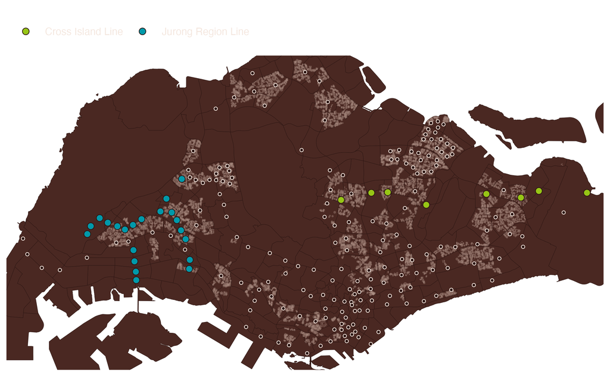

## The data were usable only after four traps were cleared

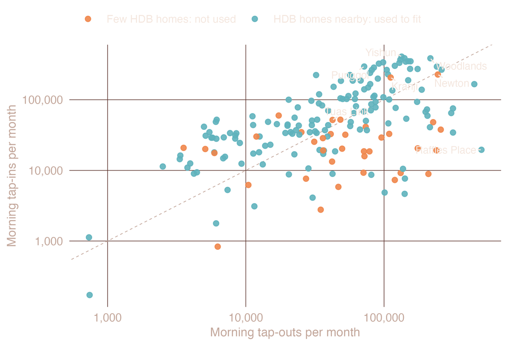

## The model shares each block’s residents among nearby stations by distance and pull

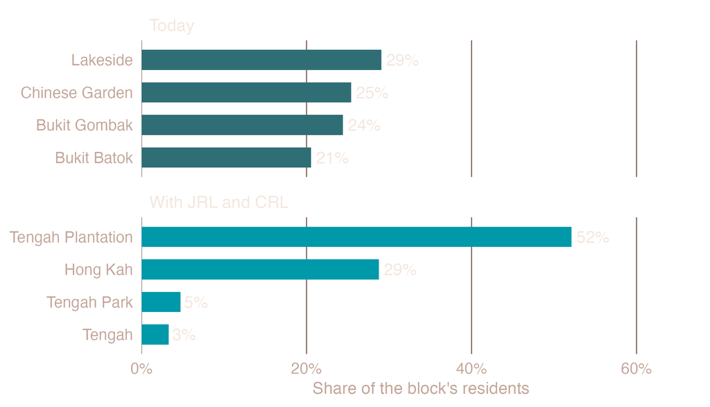

## Stations with more lines and more around them draw more riders; LRT-only stops far fewer

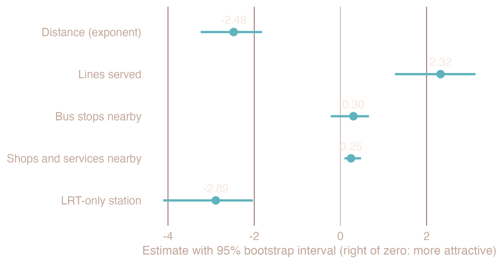

## The model ranks stations well but misses any one station by about a third

41%

textbook Huff, R² on hidden stations

75%

this model, R² on hidden stations

0.90

rank correlation

34%

typical miss, one station

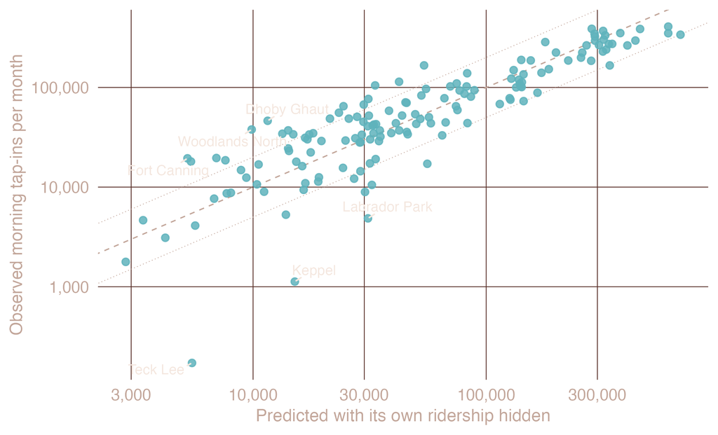

## Tengah Plantation, Serangoon North and Pasir Ris East have the most HDB residents nearby

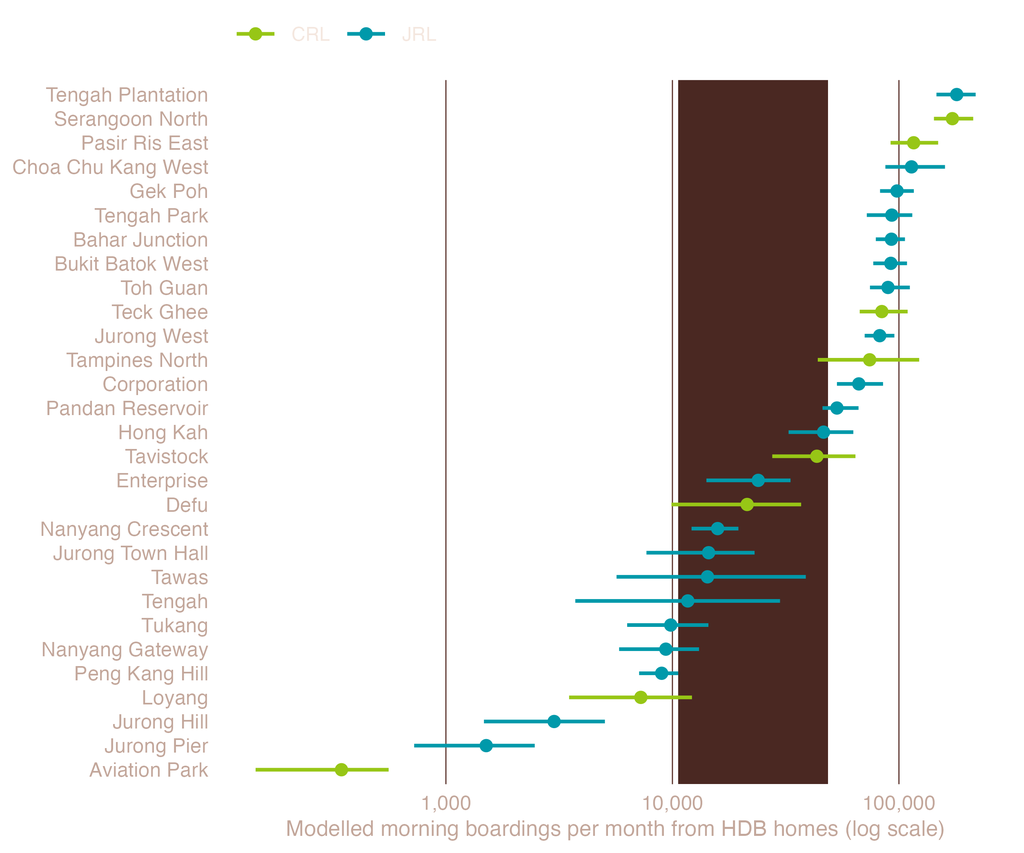

## The new lines move boardings between stations; they do not add them

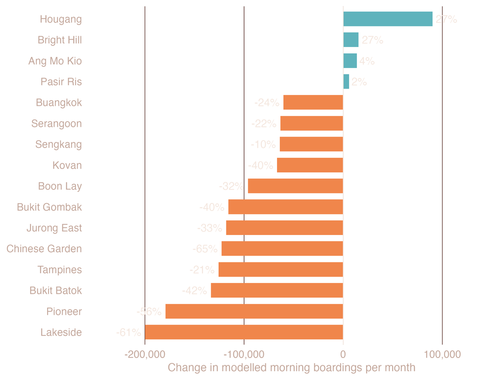

## Tengah and Jurong West gain stations of their own

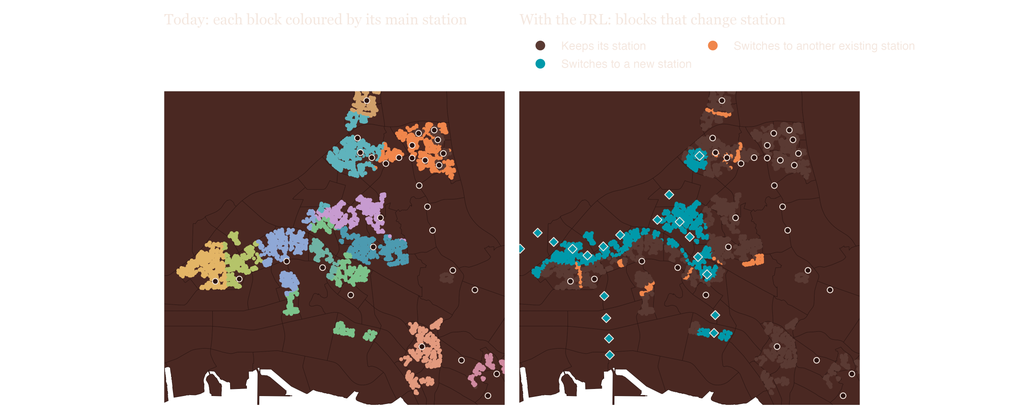

Same area and projection in both panels; circles are today’s stations, diamonds the new JRL stations. Across Singapore 1,342 of 10,817 blocks change their main station, 1,042 of them to a new one. Tengah’s blocks, today at the edge of several catchments, become the core of their own.

## Distance matters about twice as much in the North-East and West as in the centre

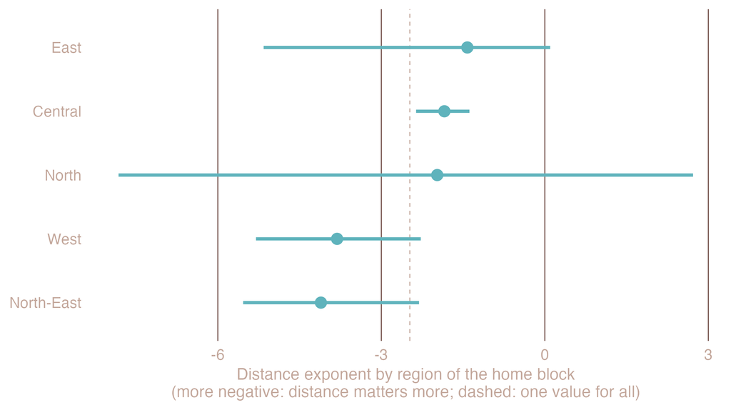

## What the model supports, what it suggests, and what evidence is still missing

Residential demand

Supports A ranking of new stations by nearby HDB residents: Tengah Plantation, Serangoon North, Pasir Ris East, Choa Chu Kang West on top.

Suggests These will be busy morning boarding points from opening.

Needs Private housing and new blocks; ridership at comparable new stations.

Jobs, campuses, airport

Supports Few HDB residents live near Aviation Park, Jurong Pier, Jurong Hill, Loyang, Tukang and the Nanyang stations.

Suggests Nothing about their total use, or about opening dates.

Needs A model of morning arrivals with jobs and student numbers, and the origin-destination data.

Existing stations

Supports Large shifts of HDB morning boardings away from Chinese Garden, Lakeside, Pioneer, Bukit Batok and Kovan.

Suggests Lighter entry and access demand at those stations.

Needs Train routing and capacity before any claim about crowding; a bus-network study before any feeder change.

Further validation

Supports The model ranks today’s stations well (0.90) and its conclusions survive the sensitivity checks.

Suggests The regional model is the better guide in the West and North-East.

Needs A before-and-after test at a real opening; walking-network distances instead of straight lines.

Source: LTA DataMall Passenger Volume by Train Stations, Aug to Oct 2026; HDB (data.gov.sg); own Huff model. The brief’s “public-safety” and “peace-keeping” implications are carry-overs from Take-home 2 and do not apply here.